# Impact of storm events between 2002 and 2011 on population health and economy

Dominik Langer

Sunday, May 24, 2015

## Synopsis

This report focuses on answering the following two questions:

1. Across the United States, which types of weather events are most harmful with respect to population health?
2. Across the United States, which types of weather events have the greatest economic consequences?

## Data Processing

### Source data

The data used for this report come in the form of a comma-separated-value file compressed via the bzip2 algorithm to reduce its size. It was downloaded from here: [Storm Data](https://d396qusza40orc.cloudfront.net/repdata%2Fdata%2FStormData.csv.bz2) (47Mb)

The following documents provide further information on the source dataset:

- [National Weather Service Storm Data Documentation](https://d396qusza40orc.cloudfront.net/repdata%2Fpeer2_doc%2Fpd01016005curr.pdf)
- [National Climatic Data Center Storm Events FAQ](https://d396qusza40orc.cloudfront.net/repdata%2Fpeer2_doc%2Fpd01016005curr.pdf)

### R packages

The code blocks in this document make use of the **dplyr**, **ggplot2**, **reshape2** and **knitr** packages:

```r
library(dplyr)
library(ggplot2)
library(reshape2)
library(knitr)

setwd("C:/Users/dlanger/Documents/GitHub/RepData_PeerAssessment2")
```

### Loading data

In a first step, the source data file was downloaded and the data loaded into memory:

```r
url <- "https://d396qusza40orc.cloudfront.net/repdata%2Fdata%2FStormData.csv.bz2"
filePath = "./data/repdata_data_StormData.csv.bz2"

if (!file.exists(filePath)) {
      download.file(url, filePath, method="internal")
}

stormData <- read.csv(bzfile(filePath), stringsAsFactors = FALSE)
```

### Filtering relevant data

The events in the dataset start in the year 1950 and end in November 2011. In the earlier years of the dataset, there are generally fewer events recorded as shown in the following plot, most likely due to a lack of good records:

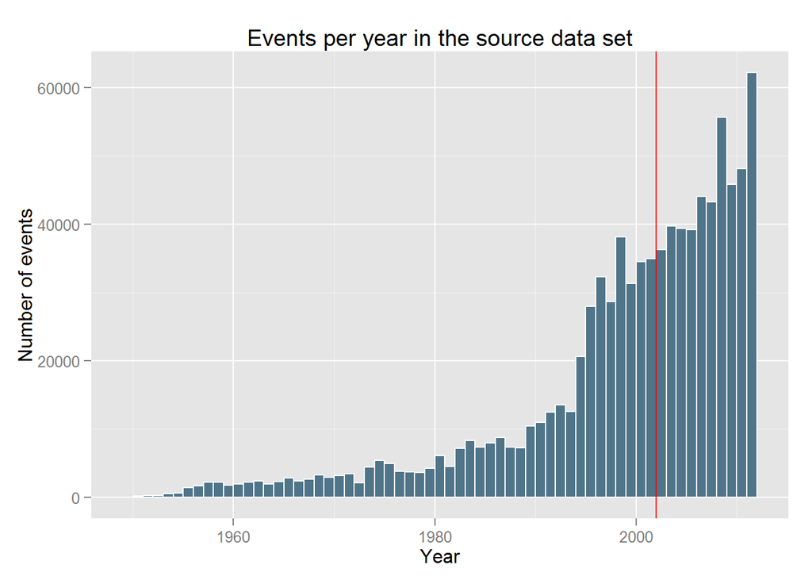

```r
stormData$beginYear <- as.numeric(format(as.Date(stormData$BGN_DATE, format = "%m/%d/%Y 0:00:00"), "%Y"))

ggplot(stormData, aes(x = beginYear)) +
      geom_histogram(binwidth=1, fill = "#507488", colour = "white") +
      geom_vline(xintercept = 2002, colour = "red") +
      xlab("Year") +
      ylab("Number of events") +
      ggtitle("Events per year in the source data set")
```

```r
startYear <- 2002
stormDataRecent <- filter(stormData, beginYear > startYear)
```

### Further preprocessing

The dataset specifies financial damage in exponential form (in thousands, millions or billions of USD). To prepare the data for summation, we **convert all amounts of money into USD** by multiplying with the proper factor:

```r
exponent <- c("K", "M", "B")
exponentFactor <- c(1E3, 1E6, 1E9)
for (i in seq_along(exponent)) {
      indices <- toupper(stormDataRecent$PROPDMGEXP) == exponent[i]
      stormDataRecent$PROPDMG[indices] <- stormDataRecent$PROPDMG[indices] * exponentFactor[i]
      stormDataRecent$PROPDMGEXP[indices] <- ""

      indices <- toupper(stormDataRecent$CROPDMGEXP) == exponent[i]
      stormDataRecent$CROPDMG[indices] <- stormDataRecent$CROPDMG[indices] * exponentFactor[i]
      stormDataRecent$CROPDMGEXP[indices] <- ""
}
```

### Data indicating impact on population health

We estimate impact on population health based on the number of fatalities and injuries, respectively, which are both specified for each event in the dataset. We independently sum up these numbers for each type of event and sort the resulting new dataset in descending order according to the number of total casualties (i.e., the sum of fatalities and injuries). We consider the five event types with the highest total number of casualties as the most harmful for population health.

```r
events.health <- filter(stormDataRecent, FATALITIES > 0 | INJURIES > 0) %>%
      group_by(EVTYPE) %>%
      summarize(Fatalities = sum(FATALITIES), Injuries = sum(INJURIES)) %>%
      mutate(totalAffected = Fatalities + Injuries) %>%
      arrange(desc(totalAffected)) %>%
      mutate(EVTYPE = factor(EVTYPE, as.character(EVTYPE)))

events.health.worst <- head(events.health, 5)
events.health.worst.melted <- melt(events.health.worst, id = "EVTYPE", measure.vars = c("Fatalities", "Injuries"))
```

### Data indicating impact on economy

We estimate impact on economy based on the financial damage caused in property and crop, respectively, which are both specified for each event in the dataset. We independently sum up these numbers for each type of event and sort the resulting new dataset in descending order according to the total financial impact (i.e., the sum of property damage and crop damage). We consider the five event types with the highest total damage as those with the greatest economic impact.

```r
events.economy <- filter(stormDataRecent, PROPDMG > 0 | CROPDMG > 0) %>%
      group_by(EVTYPE) %>%
      summarize(Property.Damage = sum(PROPDMG), Crop.Damage = sum(CROPDMG)) %>%
      mutate(totalDamage = Property.Damage + Crop.Damage) %>%
      arrange(desc(totalDamage)) %>%
      mutate(EVTYPE = factor(EVTYPE, as.character(EVTYPE)))

events.economy.worst <- head(events.economy, 5)
events.economy.worst.melted <- melt(events.economy.worst, id = "EVTYPE", measure.vars = c("Property.Damage", "Crop.Damage"))
```

## Results

### Impact on population health

```r
kable(events.health.worst, col.names = c("Type of event", "Fatalities", "Injuries", "Total casualties"))
```

| Type of event | Fatalities | Injuries | Total casualties |
| --- | --- | --- | --- |
| TORNADO | 1057 | 12620 | 13677 |
| EXCESSIVE HEAT | 524 | 2419 | 2943 |
| LIGHTNING | 319 | 1994 | 2313 |
| THUNDERSTORM WIND | 130 | 1400 | 1530 |
| HEAT | 229 | 1222 | 1451 |

The following bar plot illustrates the numbers shown in the table above in a graphical form:

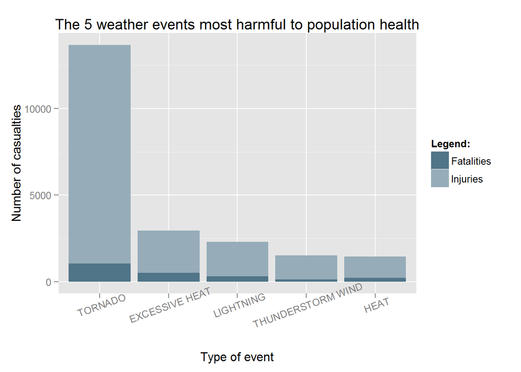

```r
ggplot(events.health.worst.melted, aes(x=EVTYPE, y=value, fill=variable)) +
      geom_bar(stat="identity") +
      scale_fill_manual(name = "Legend:  ", values = c("#507488", "#96acb9")) +
      theme(axis.text.x = element_text(angle=20)) +
      xlab("Type of event") +
      ylab("Number of casualties") +
      ggtitle("The 5 weather events most harmful to population health")
```

### Impact on economy

```r
kable(events.economy.worst, col.names = c("Type of event", "Property damage [USD]", "Crop damage [USD]", "Total damage [USD]"))
```

| Type of event | Property damage [USD] | Crop damage [USD] | Total damage [USD] |
| --- | --- | --- | --- |
| FLOOD | 132993008730 | 3519127900 | 136512136630 |
| HURRICANE/TYPHOON | 69130840000 | 2607872800 | 71738712800 |
| STORM SURGE | 43157757000 | 0 | 43157757000 |
| TORNADO | 17605668460 | 219790900 | 17825459360 |
| FLASH FLOOD | 10451154210 | 802794000 | 11253948210 |

The following bar plot illustrates the numbers shown in the table above in a graphical form:

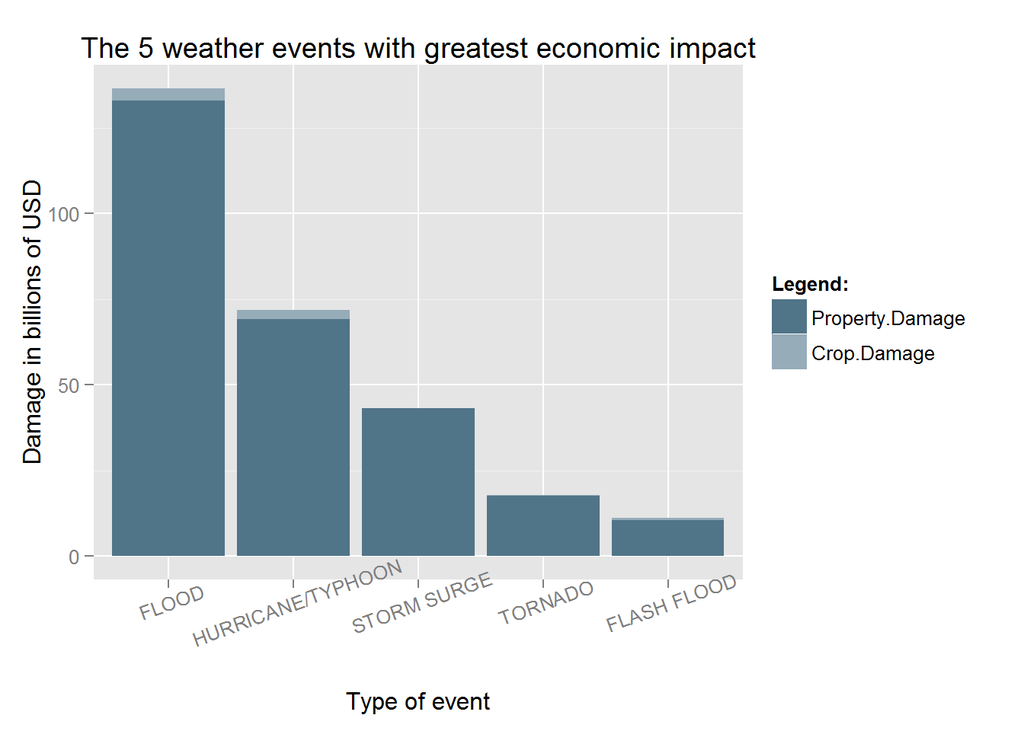

```r
ggplot(events.economy.worst.melted, aes(x = EVTYPE, y = value / 1E9, fill = variable)) +
      geom_bar(stat="identity") +
      scale_fill_manual(name = "Legend:  ", values = c("#507488", "#96acb9")) +
      theme(axis.text.x = element_text(angle=20)) +
      xlab("Type of event") +
      ylab("Damage in billions of USD") +
      ggtitle("The 5 weather events with greatest economic impact")
```

As we can see from the above results, floods have caused the greatest economic damage during analyzed period. The financial damage caused by floods in this period is nearly double as high as the one caused by hurricanes/typhoons, which are second in the ranking.